# Praca domowa 8

Piotr Obarski

Modele liniowe i mieszane

For the Drosophila study check what will happen with coefficients if:

1. all variables are included into a model and standard MLE estimates are calculated, b) ridge regression is applied, c) lasso regression is applied.

For points b) and c) present how model coefficient behaves as a function of penalty/parameter.

# Solution

Fristly load dataset and do normal linear regression with the function lm.

```r
library(ggplot2)
library(PBImisc)
attach(Drosophila)

lm(pc1~., data=bs)
```

```
##
## Call:
## lm(formula = pc1 ~ ., data = bs)
##
## Coefficients:
## (Intercept)          ewg            w           rp            v
##  -2.862e-02   -1.565e-05    4.485e-05    4.296e-05    6.476e-05
##          sd          run           gl          pgk           cg
##   1.916e-04    9.393e-06    2.928e-05   -5.883e-05   -4.209e-05
##        gpdh        ninaC          glt          mhc          ddc
##   2.662e-04    5.600e-05   -1.581e-05    6.114e-05   -1.373e-04
##         duc          sli         egfr          twi          zip
##  -1.451e-04    4.936e-05   -3.444e-05   -7.629e-05    3.292e-05
##         lsp           ve          acr          dbi            h
##  -4.000e-05    7.699e-05    2.039e-04    1.149e-04   -6.452e-05
##          fz          eip          tra          rdg           ht
##   9.746e-05    1.430e-04   -9.463e-05    9.624e-05    4.683e-05
##         ant        ninaE          fas          mst          odh
##   4.876e-05    9.992e-05    2.596e-05   -7.880e-05   -8.097e-05
##         tub           hb          rox          ald          mlc
##   1.335e-04    1.141e-04    2.164e-05   -9.623e-05    9.369e-05
##         jan          efi       adjpc1         area        areat
##  -3.317e-04    2.433e-04    3.261e-02    3.482e+00    1.957e-01
##       tibia
##   6.892e-03
```

```r
coef1<-lm(pc1~., data=bs)$coef
```

Now let’s try ridge regression. I will draw a plot only for a few coefficients, but we know that coefficients, which are close to each other, are correlated, so I chose them in a way to have coefficients which are not correlated.

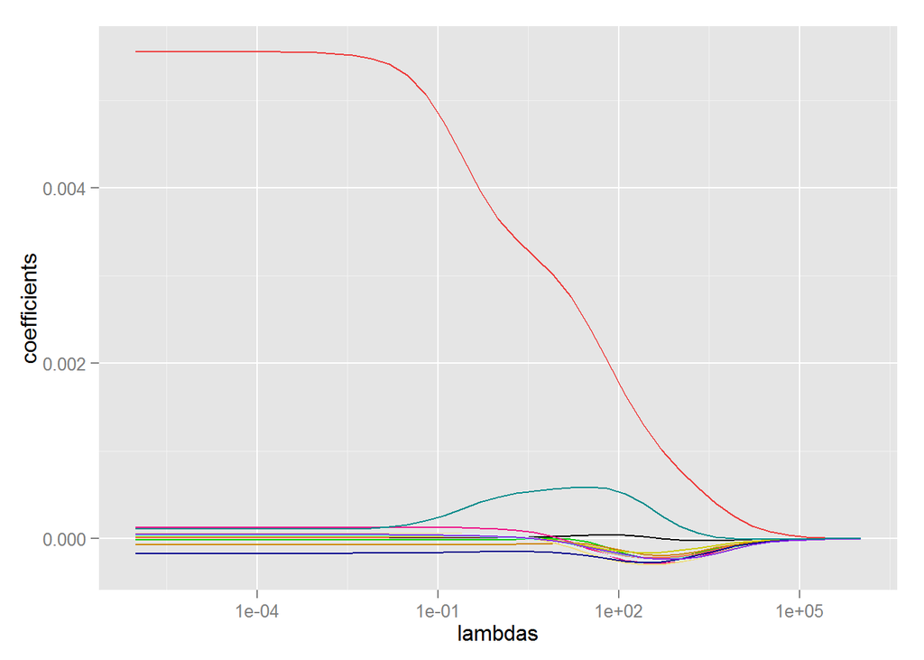

```r
lambdas <- 2^((-20):20)
coefs <- sapply(lambdas, function(lambda) {
  lm.ridge(pc1~., data=bs, lambda=lambda)$coef
})
df2 <- data.frame(t(coefs), lambdas)
ggplot(df2, aes(lambdas, ewg)) +
  geom_line(color="green3") + ylab("coefficients") +
  geom_line(aes(lambdas, run)) + scale_x_log10() +
  geom_line(aes(lambdas, gl), color="coral2") +
  geom_line(aes(lambdas, gpdh), color="deeppink2") +
  geom_line(aes(lambdas, ddc), color="orange3") +
  geom_line(aes(lambdas, sli), color="yellow3") +
  geom_line(aes(lambdas, ninaE), color="darkorchid3") +
  geom_line(aes(lambdas, ve), color="aquamarine1") +
  geom_line(aes(lambdas, dbi), color="lightgoldenrod2") +
  geom_line(aes(lambdas, rdg), color="tan") +
  geom_line(aes(lambdas, ninaE), color="azure2") +
  geom_line(aes(lambdas, jan), color="blue4") +
  geom_line(aes(lambdas, rdg), color="blueviolet") +
  geom_line(aes(lambdas, area), color="brown2") +
  geom_line(aes(lambdas, tibia), color="darkcyan")
```

We see that coefficient area differs very much from others, so let’s remove it from the plot.

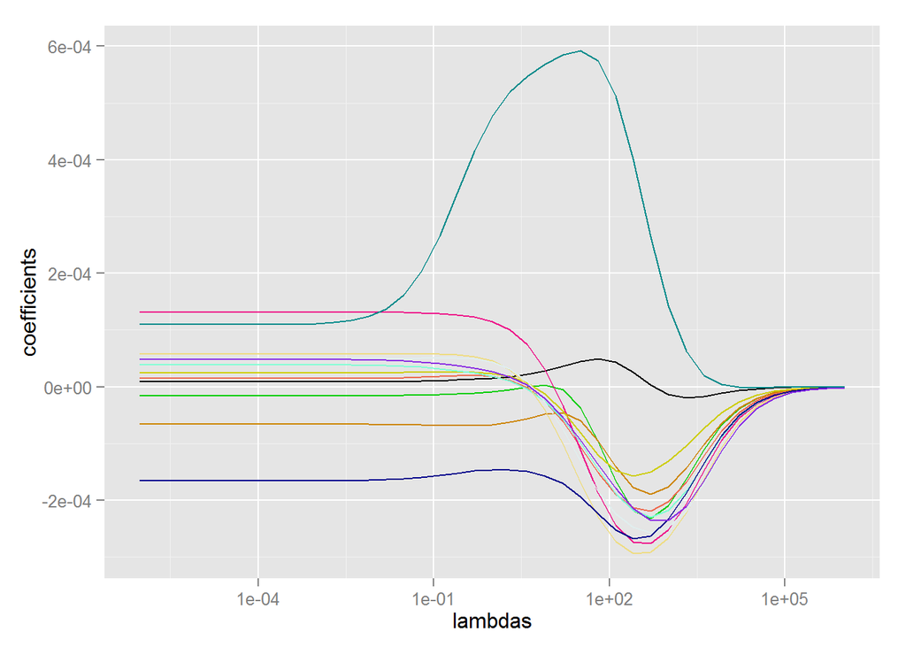

```r
ggplot(df2, aes(lambdas, ewg)) +
  geom_line(color="green3") + ylab("coefficients") +
  geom_line(aes(lambdas, run)) + scale_x_log10() +
  geom_line(aes(lambdas, gl), color="coral2") +
  geom_line(aes(lambdas, gpdh), color="deeppink2") +
  geom_line(aes(lambdas, ddc), color="orange3") +
  geom_line(aes(lambdas, sli), color="yellow3") +
  geom_line(aes(lambdas, ninaE), color="darkorchid3") +
  geom_line(aes(lambdas, ve), color="aquamarine1") +
  geom_line(aes(lambdas, dbi), color="lightgoldenrod2") +
  geom_line(aes(lambdas, rdg), color="tan") +
  geom_line(aes(lambdas, ninaE), color="azure2") +
  geom_line(aes(lambdas, jan), color="blue4") +
  geom_line(aes(lambdas, rdg), color="blueviolet") +
  geom_line(aes(lambdas, tibia), color="darkcyan")
```

From the plot we see that it can be worthwhile to do ridge regression for lambdas equal to 10, 100, and 1000000.

```r
lm.ridge(pc1~., data=bs, lambda=10)
```

```
##                         ewg             w            rp             v
## -3.544126e-02  1.908817e-06 -1.100812e-04  2.096833e-05 -9.230593e-05
##            sd           run            gl           pgk            cg
##  1.968461e-04  3.285010e-05 -7.228517e-05 -8.522894e-05 -1.240961e-04
##          gpdh         ninaC           glt           mhc           ddc
##  2.294035e-05 -1.208128e-04  1.496664e-05 -1.457074e-04 -9.581244e-05
##           duc           sli          egfr           twi           zip
## -2.454999e-04 -4.302224e-05 -3.995387e-05 -8.114679e-05 -6.108172e-05
##           lsp            ve           acr           dbi             h
## -5.515150e-05 -7.008053e-05  1.077583e-04 -1.182013e-04 -9.394948e-05
##            fz           eip           tra           rdg            ht
## -3.069596e-04  1.156560e-04 -2.747861e-05 -6.165682e-05 -1.260506e-04
##           ant         ninaE           fas           mst           odh
##  9.504649e-05 -8.410996e-05 -7.510353e-05 -1.851610e-04 -2.664293e-05
##           tub            hb           rox           ald           mlc
## -7.336584e-05  2.606030e-05 -1.622663e-04 -1.602650e-04 -2.789443e-05
##           jan           efi        adjpc1          area         areat
## -3.215488e-04  3.590061e-05  3.013747e-02  1.843724e+00  7.308358e-01
##         tibia
##  3.612135e-02
```

```r
lm.ridge(pc1~., data=bs, lambda=100)
```

```
##                         ewg             w            rp             v
## -1.560985e-02 -1.416356e-04 -3.252883e-04 -1.669967e-04 -3.311736e-04
##            sd           run            gl           pgk            cg
##  1.291080e-04  5.153698e-05 -3.557833e-04 -2.526923e-04 -4.653589e-04
##          gpdh         ninaC           glt           mhc           ddc
## -4.568981e-04 -4.522434e-04 -2.118351e-04 -5.189236e-04 -2.590318e-04
##           duc           sli          egfr           twi           zip
## -4.085543e-04 -2.822099e-04 -9.343104e-05 -1.498354e-04 -2.441488e-04
##           lsp            ve           acr           dbi             h
## -2.271427e-04 -3.479241e-04 -3.208059e-04 -5.200334e-04 -3.805771e-04
##            fz           eip           tra           rdg            ht
## -7.959885e-04 -3.045255e-04 -1.742720e-04 -3.299995e-04 -3.996110e-04
##           ant         ninaE           fas           mst           odh
## -1.915294e-04 -4.308244e-04 -4.344354e-04 -3.622114e-04 -2.429769e-04
##           tub            hb           rox           ald           mlc
## -3.851332e-04 -3.312965e-04 -4.996068e-04 -4.457904e-04 -4.086831e-04
##           jan           efi        adjpc1          area         areat
## -4.873971e-04 -3.663773e-04  2.218911e-02  1.115609e+00  4.483451e-01
##         tibia
##  3.399405e-02
```

```r
lm.ridge(pc1~., data=bs, lambda=1000000)
```

```
##                         ewg             w            rp             v
##  1.306323e-02 -7.171235e-07 -7.884405e-07 -6.040682e-07 -5.813838e-07
##            sd           run            gl           pgk            cg
## -3.533996e-07 -1.532554e-07 -1.785791e-06 -1.839063e-06 -2.115745e-06
##          gpdh         ninaC           glt           mhc           ddc
## -2.144546e-06 -2.111692e-06 -1.912751e-06 -1.669868e-06 -1.491075e-06
##           duc           sli          egfr           twi           zip
## -1.486885e-06 -1.047270e-06 -6.349580e-07 -6.430704e-07 -7.670338e-07
##           lsp            ve           acr           dbi             h
## -1.732985e-06 -2.071116e-06 -2.381698e-06 -2.535720e-06 -2.525998e-06
##            fz           eip           tra           rdg            ht
## -2.773930e-06 -2.690522e-06 -2.606506e-06 -2.878006e-06 -2.855313e-06
##           ant         ninaE           fas           mst           odh
## -2.858293e-06 -2.999947e-06 -3.110322e-06 -2.928505e-06 -2.863494e-06
##           tub            hb           rox           ald           mlc
## -2.775413e-06 -2.709129e-06 -2.507364e-06 -2.380926e-06 -2.424356e-06
##           jan           efi        adjpc1          area         areat
## -1.976179e-06 -1.803963e-06  6.025238e-05  1.816118e-03  7.882132e-04
##         tibia
## -4.986607e-06
```

```r
coef5<-lm.ridge(pc1~., data=bs, lambda=10)$coef
coef2<-lm.ridge(pc1~., data=bs, lambda=100)$coef
coef3<-lm.ridge(pc1~., data=bs, lambda=1000000)$coef
```

Let’s compute the differences of coefficients from normal regression and ridge regression.

```r
coef1-coef5
```

```
##   (Intercept)           ewg             w            rp             v
## -2.861733e-02  9.439680e-05  2.402227e-05  1.340143e-04 -1.204754e-04
##            sd           run            gl           pgk            cg
##  1.616098e-04  4.537421e-05  7.180231e-05  2.883221e-06 -5.345786e-05
##          gpdh         ninaC           glt           mhc           ddc
##  3.262002e-04  4.858638e-05  5.485070e-05  1.072806e-04 -1.822779e-05
##           duc           sli          egfr           twi           zip
## -1.238594e-04  6.930323e-05  6.092538e-06 -4.580344e-05  6.046817e-05
##           lsp            ve           acr           dbi             h
## -5.047903e-06  2.324352e-05  2.628824e-04  1.619009e-04  8.766603e-05
##            fz           eip           tra           rdg            ht
##  4.007774e-05  1.567100e-04 -6.393872e-05  1.587330e-04 -1.585569e-07
##           ant         ninaE           fas           mst           odh
##  9.009913e-05  1.370539e-04  1.179327e-04 -6.554261e-05 -4.441784e-05
##           tub            hb           rox           ald           mlc
##  1.204886e-04  1.952061e-04  1.017675e-04 -8.229001e-05  2.541255e-04
##           jan           efi        adjpc1          area         areat
## -3.495371e-04 -1.079990e-03  2.966798e-02  3.479599e+00  1.951575e-01
##         tibia
##  6.890524e-03
```

```r
coef1-coef2
```

```
##   (Intercept)           ewg             w            rp             v
## -2.847381e-02  3.095373e-04  2.107527e-04  3.696407e-04 -5.673145e-05
##            sd           run            gl           pgk            cg
##  1.445487e-04  1.864885e-04  1.553587e-04  1.725808e-04  1.842870e-04
##          gpdh         ninaC           glt           mhc           ddc
##  4.907300e-04  1.608816e-04  2.358289e-04  1.858900e-04  6.083976e-05
##           duc           sli          egfr           twi           zip
## -5.516913e-06  9.599412e-05  4.040237e-05  4.556681e-05  1.463775e-04
##           lsp            ve           acr           dbi             h
##  1.335365e-04  2.370052e-04  4.635496e-04  3.051703e-04  3.301262e-04
##            fz           eip           tra           rdg            ht
##  2.485371e-04  2.297424e-04  6.963186e-05  2.943640e-04  1.415244e-04
##           ant         ninaE           fas           mst           odh
##  2.604939e-04  3.147074e-04  2.058764e-04  4.214003e-05  1.109073e-04
##           tub            hb           rox           ald           mlc
##  2.987331e-04  3.637741e-04  2.445143e-04  1.079889e-04  3.368761e-04
##           jan           efi        adjpc1          area         areat
## -1.491189e-04 -7.309926e-04  3.082899e-02  3.480620e+00  1.951913e-01
##         tibia
##  7.034040e-03
```

```r
coef1-coef3
```

```
##   (Intercept)           ewg             w            rp             v
## -2.861470e-02 -1.486211e-05  4.545297e-05  4.353439e-05  6.509631e-05
##            sd           run            gl           pgk            cg
##  1.917419e-04  1.028236e-05  3.019467e-05 -5.777316e-05 -4.102908e-05
##          gpdh         ninaC           glt           mhc           ddc
##  2.672742e-04  5.694378e-05 -1.499529e-05  6.185372e-05 -1.365534e-04
##           duc           sli          egfr           twi           zip
## -1.446273e-04  4.967884e-05 -3.411895e-05 -7.590699e-05  3.378570e-05
##           lsp            ve           acr           dbi             h
## -3.897003e-05  7.817977e-05  2.051212e-04  1.162033e-04 -6.314903e-05
##            fz           eip           tra           rdg            ht
##  9.879149e-05  1.443356e-04 -9.319653e-05  9.765284e-05  4.824552e-05
##           ant         ninaE           fas           mst           odh
##  5.023715e-05  1.014605e-04  2.741498e-05 -7.737909e-05 -7.958659e-05
##           tub            hb           rox           ald           mlc
##  1.348384e-04  1.153751e-04  2.283431e-05 -9.501732e-05  9.467378e-05
##           jan           efi        adjpc1          area         areat
## -3.307524e-04  2.406426e-04  3.260497e-02  3.482237e+00  1.957317e-01
##         tibia
##  6.893149e-03
```

Now we do the lasso regression.

```r
library(lasso2)
```

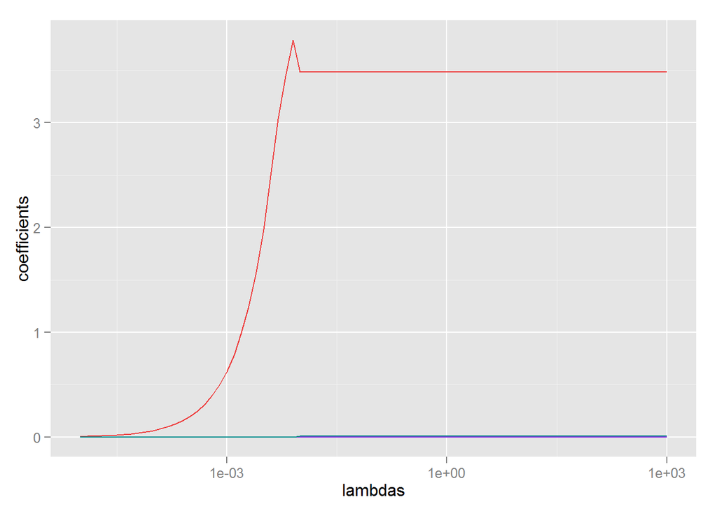

```r
lambdas <- 10^seq(-5,3,0.1)
coefs <- sapply(lambdas, function(lambda) {
  l1ce(pc1~., data=bs, bound=lambda, absolute.t=TRUE)$coef
})
df2 <- data.frame(t(coefs), lambdas)

ggplot(df2, aes(lambdas, ewg)) +
  geom_line(color="green3") + ylab("coefficients") +
  geom_line(aes(lambdas, run)) + scale_x_log10() +
  geom_line(aes(lambdas, gl), color="coral2") +
  geom_line(aes(lambdas, gpdh), color="deeppink2") +
  geom_line(aes(lambdas, ddc), color="orange3") +
  geom_line(aes(lambdas, sli), color="yellow3") +
  geom_line(aes(lambdas, ninaE), color="darkorchid3") +
  geom_line(aes(lambdas, ve), color="aquamarine1") +
  geom_line(aes(lambdas, dbi), color="lightgoldenrod2") +
  geom_line(aes(lambdas, rdg), color="tan") +
  geom_line(aes(lambdas, ninaE), color="azure2") +
  geom_line(aes(lambdas, jan), color="blue4") +
  geom_line(aes(lambdas, rdg), color="blueviolet") +
  geom_line(aes(lambdas, area), color="brown2") +
  geom_line(aes(lambdas, tibia), color="darkcyan")
```

On the plot we see that again area is the coefficient which stands out the most.

See how the plot looks without this.

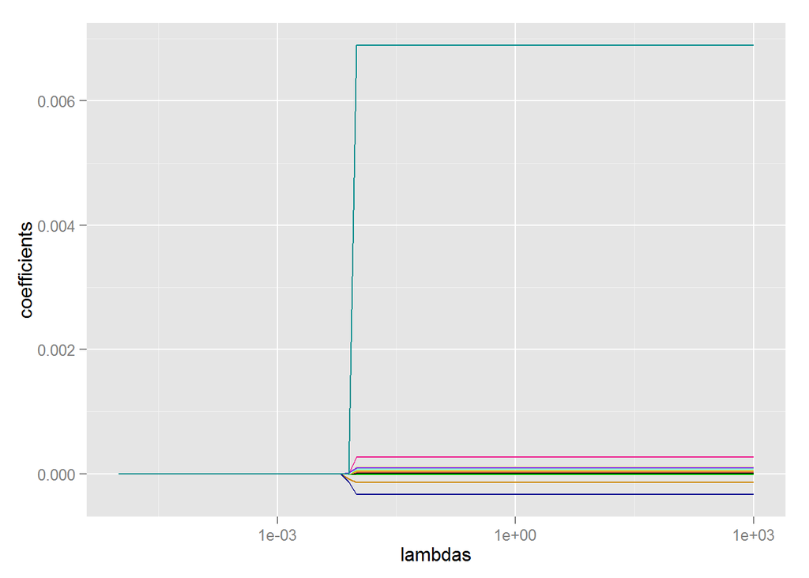

```r
ggplot(df2, aes(lambdas, ewg)) +
  geom_line(color="green3") + ylab("coefficients") +
  geom_line(aes(lambdas, run)) + scale_x_log10() +
  geom_line(aes(lambdas, gl), color="coral2") +
  geom_line(aes(lambdas, gpdh), color="deeppink2") +
  geom_line(aes(lambdas, ddc), color="orange3") +
  geom_line(aes(lambdas, sli), color="yellow3") +
  geom_line(aes(lambdas, ninaE), color="darkorchid3") +
  geom_line(aes(lambdas, ve), color="aquamarine1") +
  geom_line(aes(lambdas, dbi), color="lightgoldenrod2") +
  geom_line(aes(lambdas, rdg), color="tan") +
  geom_line(aes(lambdas, ninaE), color="azure2") +
  geom_line(aes(lambdas, jan), color="blue4") +
  geom_line(aes(lambdas, rdg), color="blueviolet") +
  geom_line(aes(lambdas, tibia), color="darkcyan")
```

Now tibia coefficient stands out the most, so remove it from the graph.

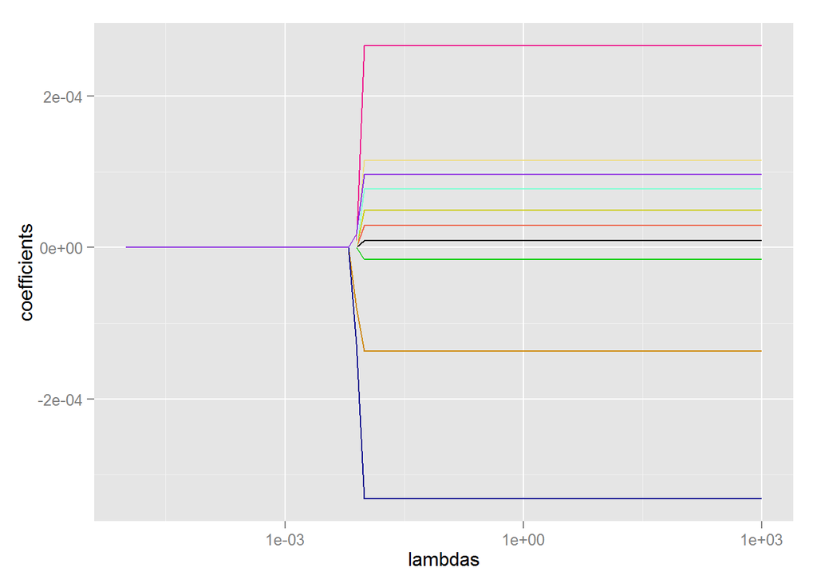

```r
ggplot(df2, aes(lambdas, ewg)) +
  geom_line(color="green3") + ylab("coefficients") +
  geom_line(aes(lambdas, run)) + scale_x_log10() +
  geom_line(aes(lambdas, gl), color="coral2") +
  geom_line(aes(lambdas, gpdh), color="deeppink2") +
  geom_line(aes(lambdas, ddc), color="orange3") +
  geom_line(aes(lambdas, sli), color="yellow3") +
  geom_line(aes(lambdas, ninaE), color="darkorchid3") +
  geom_line(aes(lambdas, ve), color="aquamarine1") +
  geom_line(aes(lambdas, dbi), color="lightgoldenrod2") +
  geom_line(aes(lambdas, rdg), color="tan") +
  geom_line(aes(lambdas, ninaE), color="azure2") +
  geom_line(aes(lambdas, jan), color="blue4") +
  geom_line(aes(lambdas, rdg), color="blueviolet")
```

It is very difficult to set a bound in lasso, beacuse all coefficients start to rise almost at the same moment, and reach their final value also almost at the same time.

```r
l1ce(pc1~., data=bs, bound=.01, absolute.t=TRUE)
```

```
## Call:
## l1ce(formula = pc1 ~ ., data = bs, bound = 0.01, absolute.t = TRUE)
##
## Coefficients:
##   (Intercept)           ewg             w            rp             v
## -2.861542e-02 -1.565031e-05  4.485287e-05  4.296090e-05  6.476375e-05
##            sd           run            gl           pgk            cg
##  1.916019e-04  9.393461e-06  2.927706e-05 -5.882524e-05 -4.209163e-05
##          gpdh         ninaC           glt           mhc           ddc
##  2.662259e-04  5.599673e-05 -1.580503e-05  6.113560e-05 -1.372744e-04
##           duc           sli          egfr           twi           zip
## -1.451455e-04  4.936192e-05 -3.444016e-05 -7.628982e-05  3.292008e-05
##           lsp            ve           acr           dbi             h
## -4.000307e-05  7.699181e-05  2.038549e-04  1.149406e-04 -6.452434e-05
##            fz           eip           tra           rdg            ht
##  9.745668e-05  1.430388e-04 -9.462909e-05  9.623717e-05  4.683238e-05
##           ant         ninaE           fas           mst           odh
##  4.876281e-05  9.992280e-05  2.596034e-05 -7.880442e-05 -8.096932e-05
##           tub            hb           rox           ald           mlc
##  1.334871e-04  1.141222e-04  2.164398e-05 -9.622876e-05  9.368776e-05
##           jan           efi        adjpc1          area         areat
## -3.316511e-04  2.432881e-04  3.260787e-02  3.482240e+00  1.957316e-01
##         tibia
##  6.892433e-03
##
## The absolute L1 bound was      : 0.01
## The Lagrangian for the bound is:  4.413787e-16
```

```r
coef4<-l1ce(pc1~., data=bs, bound=.01, absolute.t=TRUE)$coef

coef1-coef4
```

```
##   (Intercept)           ewg             w            rp             v
## -7.979728e-17  1.189234e-18 -2.026103e-18 -3.455894e-19  1.124860e-18
##            sd           run            gl           pgk            cg
##  1.192622e-18 -2.625802e-18 -2.178569e-18  1.429114e-17 -9.974660e-18
##          gpdh         ninaC           glt           mhc           ddc
## -2.710505e-19 -1.484002e-18  2.303930e-18 -1.147899e-17  1.612751e-17
##           duc           sli          egfr           twi           zip
## -6.423898e-18  3.774379e-18 -1.775381e-18 -4.784042e-18  5.224499e-18
##           lsp            ve           acr           dbi             h
## -1.768605e-18  4.119968e-18 -1.544988e-18 -1.626303e-19  6.234162e-18
##            fz           eip           tra           rdg            ht
## -9.812030e-18 -5.664956e-18  1.111307e-17 -2.276825e-18 -1.050321e-18
##           ant         ninaE           fas           mst           odh
## -3.862470e-19  1.355253e-20  5.709002e-18  1.910906e-18 -5.014435e-19
##           tub            hb           rox           ald           mlc
## -4.282599e-18  6.139295e-18 -1.406075e-18  6.098637e-19 -2.669848e-18
##           jan           efi        adjpc1          area         areat
##  5.421011e-18 -2.087089e-18  4.163336e-17 -7.105427e-15  3.858025e-15
##         tibia
##  1.335737e-16
```

```r
coef2-coef4
```

```
##   (Intercept)           ewg             w            rp             v
##  2.847381e-02 -3.095373e-04 -2.107527e-04 -3.696407e-04  5.673145e-05
##            sd           run            gl           pgk            cg
## -1.445487e-04 -1.864885e-04 -1.553587e-04 -1.725808e-04 -1.842870e-04
##          gpdh         ninaC           glt           mhc           ddc
## -4.907300e-04 -1.608816e-04 -2.358289e-04 -1.858900e-04 -6.083976e-05
##           duc           sli          egfr           twi           zip
##  5.516913e-06 -9.599412e-05 -4.040237e-05 -4.556681e-05 -1.463775e-04
##           lsp            ve           acr           dbi             h
## -1.335365e-04 -2.370052e-04 -4.635496e-04 -3.051703e-04 -3.301262e-04
##            fz           eip           tra           rdg            ht
## -2.485371e-04 -2.297424e-04 -6.963186e-05 -2.943640e-04 -1.415244e-04
##           ant         ninaE           fas           mst           odh
## -2.604939e-04 -3.147074e-04 -2.058764e-04 -4.214003e-05 -1.109073e-04
##           tub            hb           rox           ald           mlc
## -2.987331e-04 -3.637741e-04 -2.445143e-04 -1.079889e-04 -3.368761e-04
##           jan           efi        adjpc1          area         areat
##  1.491189e-04  7.309926e-04 -3.082899e-02 -3.480620e+00 -1.951913e-01
##         tibia
## -7.034040e-03
```

```r
coef3-coef4
```

```
##   (Intercept)           ewg             w            rp             v
##  2.861470e-02  1.486211e-05 -4.545297e-05 -4.353439e-05 -6.509631e-05
##            sd           run            gl           pgk            cg
## -1.917419e-04 -1.028236e-05 -3.019467e-05  5.777316e-05  4.102908e-05
##          gpdh         ninaC           glt           mhc           ddc
## -2.672742e-04 -5.694378e-05  1.499529e-05 -6.185372e-05  1.365534e-04
##           duc           sli          egfr           twi           zip
##  1.446273e-04 -4.967884e-05  3.411895e-05  7.590699e-05 -3.378570e-05
##           lsp            ve           acr           dbi             h
##  3.897003e-05 -7.817977e-05 -2.051212e-04 -1.162033e-04  6.314903e-05
##            fz           eip           tra           rdg            ht
## -9.879149e-05 -1.443356e-04  9.319653e-05 -9.765284e-05 -4.824552e-05
##           ant         ninaE           fas           mst           odh
## -5.023715e-05 -1.014605e-04 -2.741498e-05  7.737909e-05  7.958659e-05
##           tub            hb           rox           ald           mlc
## -1.348384e-04 -1.153751e-04 -2.283431e-05  9.501732e-05 -9.467378e-05
##           jan           efi        adjpc1          area         areat
##  3.307524e-04 -2.406426e-04 -3.260497e-02 -3.482237e+00 -1.957317e-01
##         tibia
## -6.893149e-03
```

```r
coef5-coef1
```

```
##   (Intercept)           ewg             w            rp             v
##  2.861733e-02 -9.439680e-05 -2.402227e-05 -1.340143e-04  1.204754e-04
##            sd           run            gl           pgk            cg
## -1.616098e-04 -4.537421e-05 -7.180231e-05 -2.883221e-06  5.345786e-05
##          gpdh         ninaC           glt           mhc           ddc
## -3.262002e-04 -4.858638e-05 -5.485070e-05 -1.072806e-04  1.822779e-05
##           duc           sli          egfr           twi           zip
##  1.238594e-04 -6.930323e-05 -6.092538e-06  4.580344e-05 -6.046817e-05
##           lsp            ve           acr           dbi             h
##  5.047903e-06 -2.324352e-05 -2.628824e-04 -1.619009e-04 -8.766603e-05
##            fz           eip           tra           rdg            ht
## -4.007774e-05 -1.567100e-04  6.393872e-05 -1.587330e-04  1.585569e-07
##           ant         ninaE           fas           mst           odh
## -9.009913e-05 -1.370539e-04 -1.179327e-04  6.554261e-05  4.441784e-05
##           tub            hb           rox           ald           mlc
## -1.204886e-04 -1.952061e-04 -1.017675e-04  8.229001e-05 -2.541255e-04
##           jan           efi        adjpc1          area         areat
##  3.495371e-04  1.079990e-03 -2.966798e-02 -3.479599e+00 -1.951575e-01
##         tibia
## -6.890524e-03
```